# 3. Microbiome description (relative abundance)

### ORDER

#### COUNTS

At order level the microbiome counts are as follows for each group and timepoint

```r
# load data
load("R_objects/Agglomerated_Cecum.RData")
params <- readRDS("R_objects/params_description.RDS")

# Remove samples with missing data
phy.use <- prune_samples(sample_names(phy.or)[!is.na(sample_data(phy.or)[,params$group_var]) & !is.na(sample_data(phy.or)[,params$time_var])], phy.or)


# Transform data
phy.rel <- transform_sample_counts(phy.use, fun = function(x) x/sum(x)*100)
dat <- psmelt(phy.rel)

# summarise per sample
sumsample <-
  dat %>%
  filter(Abundance > 0) %>%
  group_by(Sample, .data[[params$group_var]], .data[[params$time_var]]) %>%
  summarise(pct_0 = n(),
            pct_0.1 = sum(Abundance < 0.1),
            pct_0_1 = sum(Abundance >= 0.1 & Abundance < 1),
            pct_1_10 = sum(Abundance >= 1 & Abundance < 10),
            pct_10 = sum(Abundance > 10)) %>%
  pivot_longer(starts_with("pct"),
               names_to = c("Cutoff"),
               values_to = "Count") %>%
  group_by(Cutoff, .data[[params$group_var]], .data[[params$time_var]]) %>%
  summarise(mean = round(mean(Count),2),
            sd = round(sd(Count),2))

# summarise total
sumall <- dat %>%
  filter(Abundance > 0) %>%
  group_by(OTU, .data[[params$group_var]], .data[[params$time_var]]) %>%
  summarise(Abundance = mean(Abundance)) %>%
  group_by(.data[[params$group_var]], .data[[params$time_var]]) %>%
  summarise(pct_0 = n(),
            pct_0.1 = sum(Abundance < 0.1),
            pct_0_1 = sum(Abundance >= 0.1 & Abundance < 1),
            pct_1_10 = sum(Abundance >= 1 & Abundance < 10),
            pct_10 = sum(Abundance > 10)) %>%
  pivot_longer(starts_with("pct"),
               names_to = c("Cutoff"),
               values_to = "n")

# Combine
output <- full_join(sumall, sumsample) %>%
  pivot_wider(id_cols = c(Cutoff, .data[[params$time_var]]),
              names_from = .data[[params$group_var]],
              values_from = c(n, mean, sd),
              names_vary = "slowest") %>%
  mutate(Cutoff=factor(Cutoff))


levels(output$Cutoff) <- c("All", "n < 0.1%", "0.1% < n < 1.0%", "1.0% < n < 10%", "10%  < n")

# Create output table
kable(output, row.names = F,digits = 2, caption = 'Count of orders in general and per sample',align = "r") %>%
  kable_classic(full_width = F, position = "left")
```

Count of orders in general and per sample

| Cutoff | day | n_HF_CTRL | mean_HF_CTRL | sd_HF_CTRL | n_HF_PFOS | mean_HF_PFOS | sd_HF_PFOS | n_LF_CTRL | mean_LF_CTRL | sd_LF_CTRL | n_LF_PFOS | mean_LF_PFOS | sd_LF_PFOS |
| --- | --- | --- | --- | --- | --- | --- | --- | --- | --- | --- | --- | --- | --- |
| All | d08 | 21 | 16.83 | 1.60 | 21 | 16.67 | 1.86 | 21 | 17.60 | 1.14 | 22 | 18.67 | 1.63 |
| n < 0.1% | d08 | 11 | 8.17 | 1.47 | 11 | 9.17 | 1.17 | 9 | 8.00 | 1.87 | 12 | 10.33 | 2.16 |
| 0.1% < n < 1.0% | d08 | 5 | 4.67 | 1.03 | 6 | 4.17 | 0.98 | 6 | 3.80 | 1.79 | 4 | 4.17 | 2.32 |
| 1.0% < n < 10% | d08 | 2 | 1.33 | 0.82 | 1 | 1.00 | 1.10 | 4 | 3.60 | 0.89 | 4 | 2.17 | 1.47 |
| 10% < n | d08 | 3 | 2.67 | 0.52 | 3 | 2.33 | 0.82 | 2 | 2.20 | 0.45 | 2 | 2.00 | 0.00 |
| All | d21 | 22 | 18.67 | 1.37 | 24 | 18.17 | 2.23 | 20 | 17.00 | 2.00 | 22 | 18.50 | 1.64 |
| n < 0.1% | d21 | 14 | 10.50 | 2.07 | 16 | 11.17 | 2.23 | 9 | 7.83 | 2.93 | 11 | 7.50 | 3.27 |
| 0.1% < n < 1.0% | d21 | 4 | 3.83 | 0.98 | 4 | 3.33 | 1.51 | 7 | 5.33 | 1.51 | 5 | 6.50 | 2.51 |
| 1.0% < n < 10% | d21 | 2 | 2.00 | 0.89 | 2 | 1.67 | 1.03 | 2 | 1.83 | 0.75 | 4 | 2.67 | 1.75 |
| 10% < n | d21 | 2 | 2.33 | 0.52 | 2 | 2.00 | 0.89 | 2 | 2.00 | 0.00 | 2 | 1.83 | 0.41 |

#### PLOTS

To improve the interpretation of the compositional plots I will pretreat the data with three steps:

1. Filter taxa by average abundance (minimum 1 %) and rank (max 19 features + “Others”)
2. Sort the plotted taxa by full phylogeny
3. Change taxa names in plot to a letter and include table of full taxonomy

Following this I will incorporate both time_var and subject_var in the plot

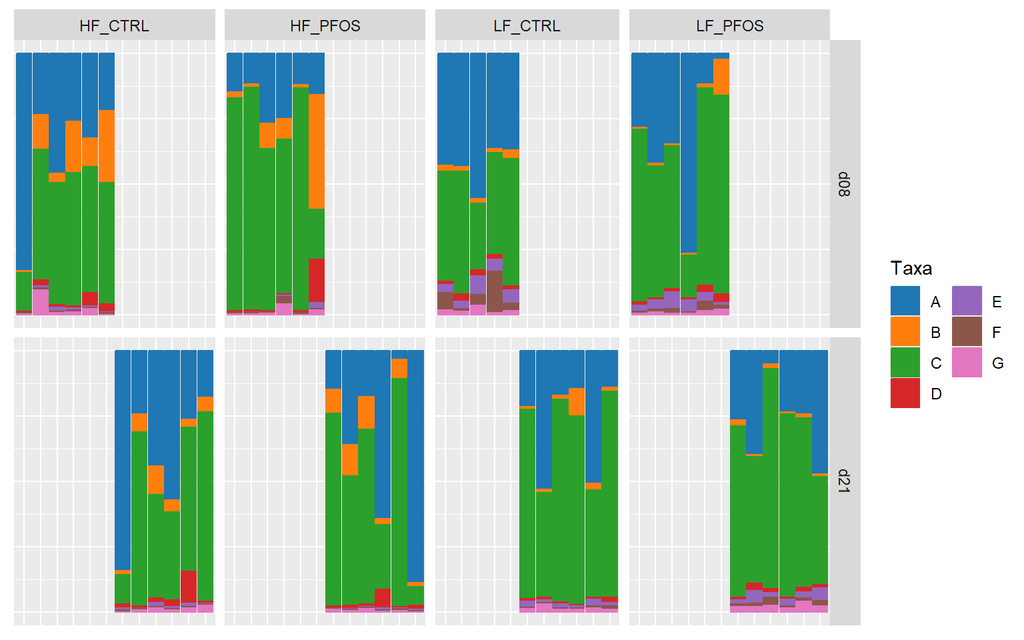

```r
# Filter by abundance, then rank
phy.top <- filter_abundance(phy.rel, group = params$group_var,includes = "any") %>% filter_rank(group = params$time_var,min.rank = 6,includes = "any")

#Melt data
dat <- suppressWarnings(psmelt(phy.top))

# Prevent duplicate column names
colnames(dat)[colnames(dat) %in% c("Taxa","SampleID")] <- paste(colnames(dat)[colnames(dat) %in% c("Taxa","SampleID")], "old", sep = "_")

# Rename relevant columns
colnames(dat)[c(1,4)] <- c("Taxa","SampleID")

# Sort taxa
dat.sort <- sort_taxa(dat)

# rename taxa
levels(dat.sort$Taxa) <- LETTERS[seq(length(levels(dat.sort$Taxa)))]

# ensure that the variables are factors
dat.sort[,params$time_var] <- factor(dat.sort[,params$time_var])
dat.sort[,params$subject_var] <- factor(dat.sort[,params$subject_var])
dat.sort[,params$group_var] <- factor(dat.sort[,params$group_var])

# Create plot
p <- ggplot(dat.sort, aes(x = .data[[params$subject_var]],
                          y = Abundance,
                          fill = Taxa,
                          color = Taxa)) +
  geom_col() +
  xlab("") +
  facet_grid(get(params$time_var) ~ get(params$group_var),
             space = "free_x",scales = "free_x") +
  ggsci::scale_color_d3(palette = "category20") +
  ggsci::scale_fill_d3(palette = "category20") +
  guides(fill=guide_legend(ncol=2), color=guide_legend(ncol=2)) +
  clean_theme()
p
```

```r
# print tax table
tax <- dat.sort %>% distinct(Taxa,.keep_all = T) %>% select(Taxa, Kingdom, Phylum, Class, Order) %>% arrange(Taxa)

kable(tax,digits = 2,caption = paste("Taxa plotted", sep = " ")) %>%
  kable_classic(full_width = F, position = "left")
```

Taxa plotted

| Taxa | Kingdom | Phylum | Class | Order |
| --- | --- | --- | --- | --- |
| A | Bacteria | Bacteroidetes | Bacteroidia | Bacteroidales |
| B | Bacteria | Firmicutes | Bacilli | Lactobacillales |
| C | Bacteria | Firmicutes | Clostridia | Clostridiales |
| D | Bacteria | Firmicutes | Erysipelotrichia | Erysipelotrichales |
| E | Bacteria | Proteobacteria | Deltaproteobacteria | Desulfovibrionales |
| F | Bacteria | Proteobacteria | Gammaproteobacteria | Enterobacterales |
| G | Others | Others | Others | Others |

```r
# clear the environment and release memory
rm(list = ls(all.names = TRUE))
invisible(gc())
```

### FAMILY

#### COUNTS

At family level the microbiome counts are as follows for each group and timepoint

```r
# load data
load("R_objects/Agglomerated_Cecum.RData")
params <- readRDS("R_objects/params_description.RDS")

# Remove samples with missing data
phy.use <- prune_samples(sample_names(phy.fa)[!is.na(sample_data(phy.fa)[,params$group_var]) & !is.na(sample_data(phy.fa)[,params$time_var])], phy.fa)

# Transform data
phy.rel <- transform_sample_counts(phy.use, fun = function(x) x/sum(x)*100)
dat <- psmelt(phy.rel)

# summarise per sample
sumsample <-
  dat %>%
  filter(Abundance > 0) %>%
  group_by(Sample, .data[[params$group_var]], .data[[params$time_var]]) %>%
  summarise(pct_0 = n(),
            pct_0.1 = sum(Abundance < 0.1),
            pct_0_1 = sum(Abundance >= 0.1 & Abundance < 1),
            pct_1_10 = sum(Abundance >= 1 & Abundance < 10),
            pct_10 = sum(Abundance > 10)) %>%
  pivot_longer(starts_with("pct"),
               names_to = c("Cutoff"),
               values_to = "Count") %>%
  group_by(Cutoff, .data[[params$group_var]], .data[[params$time_var]]) %>%
  summarise(mean = round(mean(Count),2),
            sd = round(sd(Count),2))

# summarise total
sumall <- dat %>%
  filter(Abundance > 0) %>%
  group_by(OTU, .data[[params$group_var]], .data[[params$time_var]]) %>%
  summarise(Abundance = mean(Abundance)) %>%
  group_by(.data[[params$group_var]], .data[[params$time_var]]) %>%
  summarise(pct_0 = n(),
            pct_0.1 = sum(Abundance < 0.1),
            pct_0_1 = sum(Abundance >= 0.1 & Abundance < 1),
            pct_1_10 = sum(Abundance >= 1 & Abundance < 10),
            pct_10 = sum(Abundance > 10)) %>%
  pivot_longer(starts_with("pct"),
               names_to = c("Cutoff"),
               values_to = "n")

# Combine
output <- full_join(sumall, sumsample) %>%
  pivot_wider(id_cols = c(Cutoff, .data[[params$time_var]]),
              names_from = .data[[params$group_var]],
              values_from = c(n, mean, sd),
              names_vary = "slowest") %>%
  mutate(Cutoff=factor(Cutoff))


levels(output$Cutoff) <- c("All", "n < 0.1%", "0.1% < n < 1.0%", "1.0% < n < 10%", "10%  < n")

# Create output table
kable(output, row.names = F,digits = 2, caption = 'Count of families in general and per sample',align = "r") %>%
  kable_classic(full_width = F, position = "left")
```

Count of families in general and per sample

| Cutoff | day | n_HF_CTRL | mean_HF_CTRL | sd_HF_CTRL | n_HF_PFOS | mean_HF_PFOS | sd_HF_PFOS | n_LF_CTRL | mean_LF_CTRL | sd_LF_CTRL | n_LF_PFOS | mean_LF_PFOS | sd_LF_PFOS |
| --- | --- | --- | --- | --- | --- | --- | --- | --- | --- | --- | --- | --- | --- |
| All | d08 | 45 | 34.00 | 3.03 | 44 | 34.33 | 3.98 | 46 | 38.40 | 2.51 | 44 | 37.83 | 2.99 |
| n < 0.1% | d08 | 24 | 15.83 | 3.60 | 23 | 16.50 | 3.33 | 22 | 17.40 | 3.91 | 22 | 18.67 | 3.01 |
| 0.1% < n < 1.0% | d08 | 9 | 9.67 | 2.07 | 8 | 9.00 | 2.19 | 9 | 7.40 | 2.19 | 6 | 8.33 | 1.21 |
| 1.0% < n < 10% | d08 | 8 | 6.17 | 2.32 | 10 | 6.50 | 2.07 | 11 | 10.00 | 1.41 | 12 | 7.50 | 1.52 |
| 10% < n | d08 | 4 | 2.33 | 0.82 | 3 | 2.33 | 0.82 | 4 | 3.60 | 0.55 | 4 | 3.33 | 1.03 |
| All | d21 | 46 | 36.67 | 2.42 | 47 | 35.67 | 2.66 | 44 | 35.83 | 4.17 | 47 | 39.83 | 2.64 |
| n < 0.1% | d21 | 26 | 17.67 | 2.50 | 28 | 18.67 | 3.72 | 21 | 14.67 | 4.55 | 23 | 16.00 | 3.52 |
| 0.1% < n < 1.0% | d21 | 8 | 9.00 | 2.10 | 9 | 9.17 | 2.23 | 13 | 10.83 | 1.47 | 8 | 11.33 | 1.75 |
| 1.0% < n < 10% | d21 | 9 | 7.50 | 2.35 | 8 | 5.33 | 1.37 | 6 | 7.33 | 1.51 | 13 | 9.33 | 1.21 |
| 10% < n | d21 | 3 | 2.50 | 1.05 | 2 | 2.50 | 1.38 | 4 | 3.00 | 1.41 | 3 | 3.17 | 0.41 |

#### PLOTS

To improve the interpretation of the compositional plots I will pretreat the data with three steps:

1. Filter taxa by average abundance (minimum 1 %) and rank (max 19 features + “Others”)
2. Sort the plotted taxa by full phylogeny
3. Change taxa names in plot to a letter and include table of full taxonomy

Following this I will incorporate both time_var and subject_var in the plot

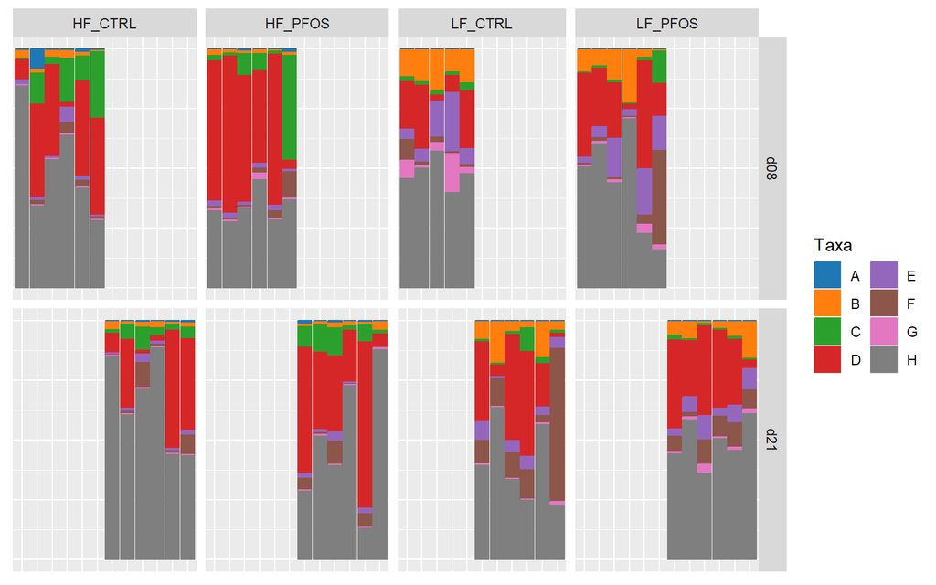

```r
# Filter by abundance, then rank
phy.top <- filter_abundance(phy.rel, group = params$group_var,includes = "any") %>% filter_rank(group = params$time_var, min.rank = 6, includes = "any")

#Melt data
dat <- suppressWarnings(psmelt(phy.top))

# Prevent duplicate column names
colnames(dat)[colnames(dat) %in% c("Taxa","SampleID")] <- paste(colnames(dat)[colnames(dat) %in% c("Taxa","SampleID")], "old", sep = "_")

# Rename relevant columns
colnames(dat)[c(1,4)] <- c("Taxa","SampleID")

# Sort taxa
dat.sort <- sort_taxa(dat)

# rename taxa
levels(dat.sort$Taxa) <- LETTERS[seq(length(levels(dat.sort$Taxa)))]

# ensure that the variables are factors
dat.sort[,params$time_var] <- factor(dat.sort[,params$time_var])
dat.sort[,params$subject_var] <- factor(dat.sort[,params$subject_var])
dat.sort[,params$group_var] <- factor(dat.sort[,params$group_var])

# Create plot
p <- ggplot(dat.sort, aes(x = .data[[params$subject_var]],
                          y = Abundance,
                          fill = Taxa,
                          color = Taxa)) +
  geom_col() +
  xlab("") +
  facet_grid(get(params$time_var) ~ get(params$group_var),
             space = "free_x",scales = "free_x") +
  ggsci::scale_color_d3(palette = "category20") +
  ggsci::scale_fill_d3(palette = "category20") +
  guides(fill=guide_legend(ncol=2), color=guide_legend(ncol=2)) +
  clean_theme()
p
```

```r
# print tax table
tax <- dat.sort %>% distinct(Taxa,.keep_all = T) %>% select(Taxa, Kingdom, Phylum, Class, Order,Family) %>% arrange(Taxa)

kable(tax,digits = 2,caption = paste("Taxa plotted", sep = " ")) %>%
  kable_classic(full_width = F, position = "left")
```

Taxa plotted

| Taxa | Kingdom | Phylum | Class | Order | Family |
| --- | --- | --- | --- | --- | --- |
| A | Bacteria | Actinobacteria | Actinobacteria | Bifidobacteriales | Bifidobacteriaceae |
| B | Bacteria | Bacteroidetes | Bacteroidia | Bacteroidales | Porphyromonadaceae |
| C | Bacteria | Firmicutes | Bacilli | Lactobacillales | Lactobacillaceae |
| D | Bacteria | Firmicutes | Clostridia | Clostridiales | Lachnospiraceae |
| E | Bacteria | Firmicutes | Clostridia | Clostridiales | Order_Clostridiales |
| F | Bacteria | Firmicutes | Clostridia | Clostridiales | Peptostreptococcaceae |
| G | Bacteria | Proteobacteria | Gammaproteobacteria | Enterobacterales | Enterobacteriaceae |
| H | Others | Others | Others | Others | Others |

```r
# clear the environment and release memory
rm(list = ls(all.names = TRUE))
invisible(gc())
```

### GENUS

#### COUNTS

At genus level the microbiome counts are as follows for each group and timepoint

```r
# load data
load("R_objects/Agglomerated_Cecum.RData")
params <- readRDS("R_objects/params_description.RDS")

# Remove samples with missing data
phy.use <- prune_samples(sample_names(phy.ge)[!is.na(sample_data(phy.ge)[,params$group_var]) & !is.na(sample_data(phy.ge)[,params$time_var])], phy.ge)

# Transform data
phy.rel <- transform_sample_counts(phy.use, fun = function(x) x/sum(x)*100)
dat <- psmelt(phy.rel)

# summarise per sample
sumsample <-
  dat %>%
  filter(Abundance > 0) %>%
  group_by(Sample, .data[[params$group_var]], .data[[params$time_var]]) %>%
  summarise(pct_0 = n(),
            pct_0.1 = sum(Abundance < 0.1),
            pct_0_1 = sum(Abundance >= 0.1 & Abundance < 1),
            pct_1_10 = sum(Abundance >= 1 & Abundance < 10),
            pct_10 = sum(Abundance > 10)) %>%
  pivot_longer(starts_with("pct"),
               names_to = c("Cutoff"),
               values_to = "Count") %>%
  group_by(Cutoff, .data[[params$group_var]], .data[[params$time_var]]) %>%
  summarise(mean = round(mean(Count),2),
            sd = round(sd(Count),2))

# summarise total
sumall <- dat %>%
  filter(Abundance > 0) %>%
  group_by(OTU, .data[[params$group_var]], .data[[params$time_var]]) %>%
  summarise(Abundance = mean(Abundance)) %>%
  group_by(.data[[params$group_var]], .data[[params$time_var]]) %>%
  summarise(pct_0 = n(),
            pct_0.1 = sum(Abundance < 0.1),
            pct_0_1 = sum(Abundance >= 0.1 & Abundance < 1),
            pct_1_10 = sum(Abundance >= 1 & Abundance < 10),
            pct_10 = sum(Abundance > 10)) %>%
  pivot_longer(starts_with("pct"),
               names_to = c("Cutoff"),
               values_to = "n")

# Combine
output <- full_join(sumall, sumsample) %>%
  pivot_wider(id_cols = c(Cutoff, .data[[params$time_var]]),
              names_from = .data[[params$group_var]],
              values_from = c(n, mean, sd),
              names_vary = "slowest") %>%
  mutate(Cutoff=factor(Cutoff))


levels(output$Cutoff) <- c("All", "n < 0.1%", "0.1% < n < 1.0%", "1.0% < n < 10%", "10%  < n")

# Create output table
kable(output, row.names = F,digits = 2, caption = 'Count of genera in general and per sample',align = "r") %>%
  kable_classic(full_width = F, position = "left")
```

Count of genera in general and per sample

| Cutoff | day | n_HF_CTRL | mean_HF_CTRL | sd_HF_CTRL | n_HF_PFOS | mean_HF_PFOS | sd_HF_PFOS | n_LF_CTRL | mean_LF_CTRL | sd_LF_CTRL | n_LF_PFOS | mean_LF_PFOS | sd_LF_PFOS |
| --- | --- | --- | --- | --- | --- | --- | --- | --- | --- | --- | --- | --- | --- |
| All | d08 | 109 | 75.83 | 8.98 | 105 | 74.17 | 9.77 | 105 | 82.00 | 8.72 | 108 | 84.83 | 10.46 |
| n < 0.1% | d08 | 58 | 42.17 | 7.68 | 62 | 42.17 | 6.85 | 60 | 44.60 | 8.88 | 67 | 51.67 | 8.87 |
| 0.1% < n < 1.0% | d08 | 28 | 20.17 | 3.82 | 24 | 19.83 | 3.54 | 25 | 20.80 | 1.48 | 20 | 17.83 | 2.32 |
| 1.0% < n < 10% | d08 | 20 | 11.33 | 3.33 | 17 | 10.50 | 4.59 | 16 | 13.60 | 1.67 | 19 | 12.50 | 1.76 |
| 10% < n | d08 | 3 | 2.17 | 0.98 | 2 | 1.67 | 1.21 | 4 | 3.00 | 0.00 | 2 | 2.83 | 0.75 |
| All | d21 | 108 | 78.00 | 9.17 | 107 | 78.17 | 7.36 | 96 | 74.83 | 9.33 | 109 | 85.67 | 8.48 |
| n < 0.1% | d21 | 62 | 43.00 | 6.78 | 64 | 46.67 | 5.13 | 54 | 39.83 | 9.58 | 64 | 44.33 | 8.50 |
| 0.1% < n < 1.0% | d21 | 24 | 20.00 | 4.00 | 26 | 20.50 | 3.02 | 28 | 21.67 | 3.98 | 24 | 24.00 | 2.45 |
| 1.0% < n < 10% | d21 | 21 | 12.67 | 4.76 | 15 | 8.83 | 3.31 | 12 | 10.67 | 2.73 | 20 | 15.17 | 2.93 |
| 10% < n | d21 | 1 | 2.33 | 1.37 | 2 | 2.17 | 1.17 | 2 | 2.67 | 1.37 | 1 | 2.17 | 1.17 |

#### PLOTS

To improve the interpretation of the compositional plots I will pretreat the data with three steps:

1. Filter taxa by average abundance (minimum 1 %) and rank (max 19 features + “Others”)
2. Sort the plotted taxa by full phylogeny
3. Change taxa names in plot to a letter and include table of full taxonomy

Following this I will incorporate both time_var and subject_var in the plot

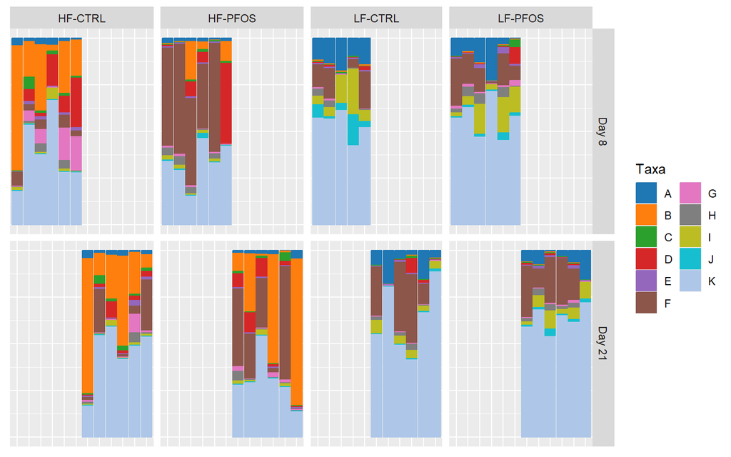

```r
# Filter by abundance, then rank
phy.top <- filter_abundance(phy.rel, group = params$group_var,includes = "any") %>% filter_rank(group = params$time_var, min.rank = 6, includes = "any")

#Melt data
dat <- suppressWarnings(psmelt(phy.top))

# Prevent duplicate column names
colnames(dat)[colnames(dat) %in% c("Taxa","SampleID")] <- paste(colnames(dat)[colnames(dat) %in% c("Taxa","SampleID")], "old", sep = "_")

# Rename relevant columns
colnames(dat)[c(1,4)] <- c("Taxa","SampleID")

# Sort taxa
dat.sort <- sort_taxa(dat)

# rename taxa
levels(dat.sort$Taxa) <- LETTERS[seq(length(levels(dat.sort$Taxa)))]

# ensure that the variables are factors
dat.sort[,params$time_var] <- factor(dat.sort[,params$time_var])
dat.sort[,params$subject_var] <- factor(dat.sort[,params$subject_var])
dat.sort[,params$group_var] <- factor(dat.sort[,params$group_var])

# Create plot
p <- ggplot(dat.sort, aes(x = .data[[params$subject_var]],
                          y = Abundance,
                          fill = Taxa,
                          color = Taxa)) +
  geom_col() +
  xlab("") +
  facet_grid(day ~ feed_treat,
             space = "free_x",scales = "free_x",
             labeller = labeller(day = c("d0" = "Day 0", "d08" = "Day 8", "d12" = "Day 12", "d16" = "Day 16", "d20" = "Day 20", "d21" = "Day 21"),
                                 feed_treat = c("HF_CTRL" = "HF-CTRL","HF_PFOS"="HF-PFOS","LF_CTRL"="LF-CTRL","LF_PFOS"="LF-PFOS"))) +
  ggsci::scale_color_d3(palette = "category20") +
  ggsci::scale_fill_d3(palette = "category20") +
  guides(fill=guide_legend(ncol=2), color=guide_legend(ncol=2)) +
  clean_theme()
p
```

```r
p.fig <- p + theme_pubr(legend = "right", border = TRUE) + theme(axis.text.x = element_text(angle = 90))

if (!file.exists(paste0("plots/relative_abundance"))) dir.create(file.path(getwd(), paste0("plots/relative_abundance")))
ggsave(filename = "plots/figures/Genus_abundance_caecum.png", plot = p.fig, device = "png", units = "mm", width = 300, height = 185, dpi = 300)
ggsave(filename = "plots/figures/Genus_abundance_caecum.pdf", plot = p.fig, device = "pdf", units = "mm", width = 300, height = 185, dpi = 300)

# print tax table
tax <- dat.sort %>% distinct(Taxa,.keep_all = T) %>% select(Taxa, Kingdom, Phylum, Class, Order,Family,Genus)  %>% arrange(Taxa)

kable(tax,digits = 2,caption = paste("Taxa plotted", sep = " ")) %>%
  kable_classic(full_width = F, position = "left")
```

Taxa plotted

| Taxa | Kingdom | Phylum | Class | Order | Family | Genus |
| --- | --- | --- | --- | --- | --- | --- |
| A | Bacteria | Bacteroidetes | Bacteroidia | Bacteroidales | Porphyromonadaceae | Parabacteroides |
| B | Bacteria | Bacteroidetes | Bacteroidia | Bacteroidales | Prevotellaceae | Prevotella |
| C | Bacteria | Firmicutes | Bacilli | Lactobacillales | Lactobacillaceae | Lactobacillus |
| D | Bacteria | Firmicutes | Bacilli | Lactobacillales | Lactobacillaceae | Ligilactobacillus |
| E | Bacteria | Firmicutes | Clostridia | Clostridiales | Lachnospiraceae | Faecalicatena |
| F | Bacteria | Firmicutes | Clostridia | Clostridiales | Lachnospiraceae | Family_Lachnospiraceae |
| G | Bacteria | Firmicutes | Clostridia | Clostridiales | Lachnospiraceae | Roseburia |
| H | Bacteria | Firmicutes | Clostridia | Clostridiales | Lachnospiraceae | Sellimonas |
| I | Bacteria | Firmicutes | Clostridia | Clostridiales | Order_Clostridiales | Order_Clostridiales |
| J | Bacteria | Proteobacteria | Gammaproteobacteria | Enterobacterales | Enterobacteriaceae | Escherichia/Shigella |
| K | Others | Others | Others | Others | Others | Others |

```r
# clear the environment and release memory
rm(list = ls(all.names = TRUE))
invisible(gc())
```

### SPECIES

#### COUNTS

At species level the microbiome counts are as follows for each group and timepoint

```r
# load data
load("R_objects/Agglomerated_Cecum.RData")
params <- readRDS("R_objects/params_description.RDS")

# Remove samples with missing data
phy.use <- prune_samples(sample_names(phy.sp)[!is.na(sample_data(phy.sp)[,params$group_var]) & !is.na(sample_data(phy.sp)[,params$time_var])], phy.sp)

# Transform data
phy.rel <- transform_sample_counts(phy.use, fun = function(x) x/sum(x)*100)
dat <- psmelt(phy.rel)

# summarise per sample
sumsample <-
  dat %>%
  filter(Abundance > 0) %>%
  group_by(Sample, .data[[params$group_var]], .data[[params$time_var]]) %>%
  summarise(pct_0 = n(),
            pct_0.1 = sum(Abundance < 0.1),
            pct_0_1 = sum(Abundance >= 0.1 & Abundance < 1),
            pct_1_10 = sum(Abundance >= 1 & Abundance < 10),
            pct_10 = sum(Abundance > 10)) %>%
  pivot_longer(starts_with("pct"),
               names_to = c("Cutoff"),
               values_to = "Count") %>%
  group_by(Cutoff, .data[[params$group_var]], .data[[params$time_var]]) %>%
  summarise(mean = round(mean(Count),2),
            sd = round(sd(Count),2))

# summarise total
sumall <- dat %>%
  filter(Abundance > 0) %>%
  group_by(OTU, .data[[params$group_var]], .data[[params$time_var]]) %>%
  summarise(Abundance = mean(Abundance)) %>%
  group_by(.data[[params$group_var]], .data[[params$time_var]]) %>%
  summarise(pct_0 = n(),
            pct_0.1 = sum(Abundance < 0.1),
            pct_0_1 = sum(Abundance >= 0.1 & Abundance < 1),
            pct_1_10 = sum(Abundance >= 1 & Abundance < 10),
            pct_10 = sum(Abundance > 10)) %>%
  pivot_longer(starts_with("pct"),
               names_to = c("Cutoff"),
               values_to = "n")

# Combine
output <- full_join(sumall, sumsample) %>%
  pivot_wider(id_cols = c(Cutoff, .data[[params$time_var]]),
              names_from = .data[[params$group_var]],
              values_from = c(n, mean, sd),
              names_vary = "slowest") %>%
  mutate(Cutoff=factor(Cutoff))


levels(output$Cutoff) <- c("All", "n < 0.1%", "0.1% < n < 1.0%", "1.0% < n < 10%", "10%  < n")

# Create output table
kable(output, row.names = F,digits = 2, caption = 'Count of species in general and per sample',align = "r") %>%
  kable_classic(full_width = F, position = "left")
```

Count of species in general and per sample

| Cutoff | day | n_HF_CTRL | mean_HF_CTRL | sd_HF_CTRL | n_HF_PFOS | mean_HF_PFOS | sd_HF_PFOS | n_LF_CTRL | mean_LF_CTRL | sd_LF_CTRL | n_LF_PFOS | mean_LF_PFOS | sd_LF_PFOS |
| --- | --- | --- | --- | --- | --- | --- | --- | --- | --- | --- | --- | --- | --- |
| All | d08 | 139 | 94.50 | 12.06 | 139 | 92.17 | 14.74 | 140 | 105.00 | 11.92 | 141 | 106.33 | 14.47 |
| n < 0.1% | d08 | 79 | 55.33 | 12.74 | 87 | 54.50 | 11.15 | 86 | 60.60 | 12.84 | 92 | 67.17 | 14.18 |
| 0.1% < n < 1.0% | d08 | 38 | 25.50 | 3.73 | 33 | 25.33 | 4.23 | 32 | 26.20 | 2.59 | 27 | 23.00 | 2.53 |
| 1.0% < n < 10% | d08 | 19 | 11.67 | 3.27 | 17 | 10.67 | 5.47 | 19 | 15.80 | 1.64 | 20 | 13.83 | 2.93 |
| 10% < n | d08 | 3 | 2.00 | 0.63 | 2 | 1.67 | 1.21 | 3 | 2.40 | 0.55 | 2 | 2.33 | 0.82 |
| All | d21 | 135 | 95.67 | 11.15 | 138 | 97.33 | 8.38 | 126 | 93.17 | 11.79 | 148 | 109.83 | 11.70 |
| n < 0.1% | d21 | 77 | 53.50 | 9.89 | 85 | 60.67 | 7.84 | 78 | 53.00 | 11.64 | 98 | 64.17 | 12.66 |
| 0.1% < n < 1.0% | d21 | 37 | 27.83 | 2.93 | 40 | 25.67 | 2.94 | 32 | 25.67 | 3.56 | 26 | 26.83 | 1.72 |
| 1.0% < n < 10% | d21 | 20 | 12.17 | 3.76 | 11 | 8.83 | 3.54 | 14 | 12.17 | 3.13 | 23 | 17.00 | 3.85 |
| 10% < n | d21 | 1 | 2.17 | 1.17 | 2 | 2.17 | 1.17 | 2 | 2.33 | 1.03 | 1 | 1.83 | 1.17 |

#### PLOTS

To improve the interpretation of the compositional plots I will pretreat the data with three steps:

1. Filter taxa by average abundance (minimum 1 %) and rank (max 19 features + “Others”)
2. Sort the plotted taxa by full phylogeny
3. Change taxa names in plot to a letter and include table of full taxonomy

Following this I will incorporate both time_var and subject_var in the plot

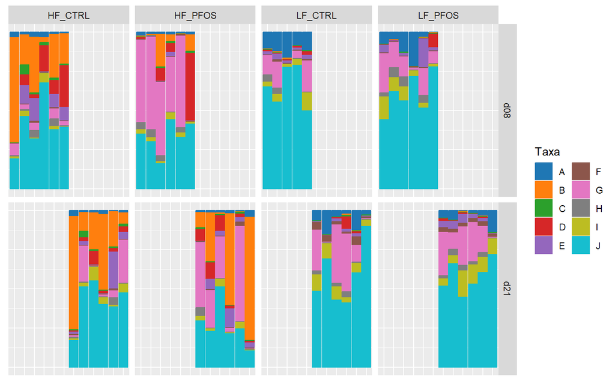

```r
# Filter by abundance, then rank
phy.top <- filter_abundance(phy.rel, group = params$group_var,includes = "any") %>% filter_rank(group = params$time_var, min.rank = 6, includes = "any")

#Melt data
dat <- suppressWarnings(psmelt(phy.top))

# Prevent duplicate column names
colnames(dat)[colnames(dat) %in% c("Taxa","SampleID")] <- paste(colnames(dat)[colnames(dat) %in% c("Taxa","SampleID")], "old", sep = "_")

# Rename relevant columns
colnames(dat)[c(1,4)] <- c("Taxa","SampleID")

# Sort taxa
dat.sort <- sort_taxa(dat)

# rename taxa
levels(dat.sort$Taxa) <- LETTERS[seq(length(levels(dat.sort$Taxa)))]

# ensure that the variables are factors
dat.sort[,params$time_var] <- factor(dat.sort[,params$time_var])
dat.sort[,params$subject_var] <- factor(dat.sort[,params$subject_var])
dat.sort[,params$group_var] <- factor(dat.sort[,params$group_var])

# Create plot
p <- ggplot(dat.sort, aes(x = .data[[params$subject_var]],
                          y = Abundance,
                          fill = Taxa,
                          color = Taxa)) +
  geom_col() +
  xlab("") +
  facet_grid(get(params$time_var) ~ get(params$group_var),
             space = "free_x",scales = "free_x") +
  ggsci::scale_color_d3(palette = "category20") +
  ggsci::scale_fill_d3(palette = "category20") +
  guides(fill=guide_legend(ncol=2), color=guide_legend(ncol=2)) +
  clean_theme()
p
```

```r
# print tax table
tax <- dat.sort %>% distinct(Taxa,.keep_all = T) %>% select(Taxa, Kingdom, Phylum, Class, Order,Family,Genus,Species) %>% arrange(Taxa)

kable(tax,digits = 2,caption = paste("Taxa plotted", sep = " ")) %>%
  kable_classic(full_width = F, position = "left")
```

Taxa plotted

| Taxa | Kingdom | Phylum | Class | Order | Family | Genus | Species |
| --- | --- | --- | --- | --- | --- | --- | --- |
| A | Bacteria | Bacteroidetes | Bacteroidia | Bacteroidales | Porphyromonadaceae | Parabacteroides | distasonis |
| B | Bacteria | Bacteroidetes | Bacteroidia | Bacteroidales | Prevotellaceae | Prevotella | Genus_Prevotella |
| C | Bacteria | Firmicutes | Bacilli | Lactobacillales | Lactobacillaceae | Lactobacillus | intestinalis |
| D | Bacteria | Firmicutes | Bacilli | Lactobacillales | Lactobacillaceae | Ligilactobacillus | Genus_Ligilactobacillus |
| E | Bacteria | Firmicutes | Clostridia | Clostridiales | Lachnospiraceae | Blautia | Genus_Blautia |
| F | Bacteria | Firmicutes | Clostridia | Clostridiales | Lachnospiraceae | Butyrivibrio | Genus_Butyrivibrio |
| G | Bacteria | Firmicutes | Clostridia | Clostridiales | Lachnospiraceae | Family_Lachnospiraceae | Family_Lachnospiraceae |
| H | Bacteria | Firmicutes | Clostridia | Clostridiales | Lachnospiraceae | Sellimonas | Genus_Sellimonas |
| I | Bacteria | Firmicutes | Clostridia | Clostridiales | Ruminococcaceae | Family_Ruminococcaceae | Family_Ruminococcaceae |
| J | Others | Others | Others | Others | Others | Others | Others |

```r
# clear the environment and release memory
rm(list = ls(all.names = TRUE))
invisible(gc())
```

# SPECIAL FIGURES FOR ARTICLE

## Figure A.5: PHYLA

### Prep data

```r
# load data
load("R_objects/Agglomerated.RData")
rm(phy.sp, phy.ge, phy.fa, phy.or, phy.cl)
params <- readRDS("R_objects/params_description.RDS")
LIST.DAY <- c("d0","d08","d12","d16","d21", "all")
DIETS <- c("HF","LF")
LIST.TR <- c("CTRL","PFOS", "both")
LVL <- "Phylum"

# Prepare dataframe
df <- data.frame()

# Run calculations
suppressMessages({suppressWarnings({
for (DIET in DIETS) {
  load("R_objects/Agglomerated.RData")
  phy.feed <- phy.ph
  phy.feed <- subset_samples(phy.feed, feed == DIET)

  for (DAY in LIST.DAY) {
    if (DAY == "all") {
      print("## All days selected")
      phy.day <- phy.feed
    } else {
      print(paste0("## Day ",DAY," selected"))
      phy.day <- subset_samples(phy.feed, day == DAY)
    }

    for (TR in LIST.TR) {
      if (TR == "both") {
        # print("## Both treatment groups selected")
        phy.tr <- phy.day
      } else {
        # print(paste0("## Treatment ",TR," selected"))
        phy.tr <- subset_samples(phy.day, treatment == TR)
      }
      # Transform data
      phy.rel <- transform_sample_counts(phy.tr, fun = function(x) x/sum(x)*100)
      dat <- psmelt(phy.rel)

      # Filter by abundance, then rank
      phy.top <- filter_abundance(phy.rel) %>% filter_rank(min.rank = 19)

      #Melt data
      dat <- suppressWarnings(psmelt(phy.top))

      # Prevent duplicate column names
      colnames(dat)[colnames(dat) %in% c("Taxa","SampleID")] <- paste(colnames(dat)[colnames(dat) %in% c("Taxa","SampleID")], "old", sep = "_")

      # Rename relevant columns
      colnames(dat)[c(1,4)] <- c("Taxa","SampleID")

      # Sort taxa
      dat.sort <- sort_taxa(dat)

      # rename taxa
      levels(dat.sort$Taxa) <- LETTERS[seq(length(levels(dat.sort$Taxa)))]

      # print tax table
      tax <- dat.sort %>% group_by(Taxa, Kingdom, Phylum) %>% summarise(Abundance = mean(Abundance))

      # Bacteroidetes-Firmicutes ratio
      Ba <- subset(tax, Phylum == "Bacteroidetes")
      Fi <- subset(tax, Phylum == "Firmicutes")
      Pb <- subset(tax, Phylum == "Proteobacteria")
      if (nrow(Pb) == 0) {
        print(paste0("Zero Preoteobacteria in ",DIET," ",DAY," ",TR))
        df_0 <- c("D","Bacteria","Proteobacteria",0)
        Pb <- data.frame()
        Pb <- rbind(Pb,df_0)
        colnames(Pb) <- c("Taxa","Kingdom","Phylum","Abundance")
        Pb <- transform(Pb, Abundance = as.numeric(Abundance))
        } else {}
      Ac <- subset(tax, Phylum == "Actinobacteria")
      if (nrow(Ac) == 0) {
        print(paste0("Zero Actinobacteria in ",DIET," ",DAY," ",TR))
        df_0 <- c("A","Bacteria","Actinobacteria",0)
        Ac <- data.frame()
        Ac <- rbind(Ac,df_0)
        colnames(Ac) <- c("Taxa","Kingdom","Phylum","Abundance")
        Ac <- transform(Ac, Abundance = as.numeric(Abundance))
        } else {}
      OT_FB <- 100 - (round(Fi$Abundance,3) + round(Ba$Abundance,3))
      OT_ALL <- 100 - (round(Fi$Abundance,3) + round(Ba$Abundance,3) + round(Pb$Abundance,3) + round(Ac$Abundance,3))
      FBR <- Fi$Abundance / Ba$Abundance

      output <- c(DIET, DAY, TR, paste0(DIET,"_",TR), round(Fi$Abundance,3), round(Ba$Abundance,3),round(Pb$Abundance,3),round(Ac$Abundance,3), OT_FB, OT_ALL, FBR) #round(Ab$Abundance,3),

      df <- rbind(df, output)

    }
  }
}
 })})

# Names columns
colnames(df) <- c("feed","day","treatment","feed_treat",
                  "Firmicutes","Bacteroidetes","Proteobacteria","Actinobacteria","Others_FB","Others_all","FB_ratio")
df
df <- transform(df, Firmicutes = as.numeric(Firmicutes),
                Bacteroidetes = as.numeric(Bacteroidetes),
                Proteobacteria = as.numeric(Proteobacteria),
                Actinobacteria = as.numeric(Actinobacteria),
                Others_FB = as.numeric(Others_FB),
                Others_all = as.numeric(Others_all),
                FB_ratio = as.numeric(FB_ratio))
df
write.csv(df, file = "plots/relative_abundance/Phyla_relative_abundance.csv")

# Prepare Firmicutes and Bacteroidetes for plotting
df.fb <- pivot_longer(df, cols = c(Firmicutes, Bacteroidetes, Others_FB), names_to = "Phylum", values_to = "Abundance")
df.fb <- subset(df.fb, treatment != "both" & day != "all")
df.fb

# Plot Firmicutes + Bacteroidetes
p <- ggplot(df.fb, aes(fill = Phylum, y = Abundance, x = feed)) +
  geom_bar(position = "fill", stat = "identity") +
  facet_grid(treatment ~ day, labeller = labeller(day = c("d0" = "Day 0","d08" = "Day 8","d12" = "Day 12","d16" = "Day 16","d21" = "Day 21"))) +
  geom_text(aes(label = paste0(round(Abundance,2),"%")), position = position_fill(vjust = 0.5), size = 3, color = "#222222") +
  ggsci::scale_fill_d3(palette = "category20", name = "Phylum", labels = c("Others_FB" = "Others")) +
  scale_y_continuous(labels = function(x) paste0(x*100, "%"), name = "Relative Abundance") +
  theme_pubr(legend = "top", border = TRUE) +
  theme(axis.title.x = element_blank())

p

ggsave(filename = "plots/relative_abundance/Firmicutes-Bacteroidetes-ratios.png", plot = p, device = "png", unit = "mm", dpi = 300, height = 150, width = 200)
ggsave(filename = "plots/relative_abundance/Firmicutes-Bacteroidetes-ratios.pdf", plot = p, device = "pdf", unit = "mm", dpi = 300, height = 150, width = 200)

# Prepare All for plotting
df.all <- pivot_longer(df, cols = c(Firmicutes, Bacteroidetes, Proteobacteria, Actinobacteria, Others_all), names_to = "Phylum", values_to = "Abundance")
df.both <- subset(df.all, treatment == "both" & day != "all")
df.both
df.all <- subset(df.all, treatment != "both" & day != "all")
df.all

l <- c("Firmicutes", "Bacteroidetes", "Proteobacteria", "Actinobacteria", "Others_all")

df.all$Phylum <- factor(df.all$Phylum, levels = c(l))

if (!file.exists("plots/figures/objects")) dir.create(file.path(getwd(), "plots/figures/objects"))
save(df,df.fb,df.all,df.both, file = "plots/figures/objects/phyla_means.Rdata")
```

The following section compare relative abundances and the ratio between Firmicutes and Bacteroidetes in data daily and in respect to factors such as HF/LF feed and PFOS exposure.

### Create Figure A.5 with supplements

```r
load("R_objects/Agglomerated.RData")
load("plots/figures/objects/phyla_means.Rdata")
params <- readRDS("R_objects/params_description.RDS")
LVL <- "Phylum"
phy.used <- phy.ph

# Transform data
phy.rel <- transform_sample_counts(phy.used, fun = function(x) x/sum(x)*100)
dat <- psmelt(phy.rel)
# Filter by abundance, then rank
phy.top <- filter_abundance(phy.rel) %>% filter_rank(min.rank = 19)
```

```
## 4 features grouped as 'Others' in the output
```

```
## 1 features grouped as 'Others' in the output
```

```r
#Melt data
dat <- suppressWarnings(psmelt(phy.top))

# Prevent duplicate column names
colnames(dat)[colnames(dat) %in% c("Taxa","SampleID")] <- paste(colnames(dat)[colnames(dat) %in% c("Taxa","SampleID")], "old", sep = "_")

# Rename relevant columns
colnames(dat)[c(1,4)] <- c("Taxa","SampleID")

# Sort taxa
dat.sort <- sort_taxa(dat)

# # rename taxa
levels(dat.sort$Taxa) <- LETTERS[seq(length(levels(dat.sort$Taxa)))]

# print tax table
tax <- dat.sort %>% group_by(Taxa, Kingdom, Phylum, day, feed) %>% summarise(Abundance = mean(Abundance))
tax <- subset(tax, Phylum %in% c("Firmicutes", "Bacteroidetes", "Proteobacteria"))

# Subset to phyla and order
dat.used <- subset(dat.sort, Phylum %in% c("Firmicutes", "Bacteroidetes", "Proteobacteria"))
df.all <- subset(df.all, Phylum %in% c("Firmicutes", "Bacteroidetes", "Proteobacteria"))
l <- c("Firmicutes", "Bacteroidetes", "Proteobacteria", "Actinobacteria","Others")
d <- c("d21","d16","d12","d08","d0")

dat.used$Phylum <- factor(dat.used$Phylum, levels = c(l))
dat.used$day <- factor(dat.used$day, levels = c(d))

df.all$Phylum <- factor(df.all$Phylum, levels = c(l))
df.all$day <- factor(df.all$day, levels = c(d))

tax$Phylum <- factor(tax$Phylum, levels = c(l))
tax$day <- factor(tax$day, levels = c(d))

# Set parameters
PREDICTOR <- c("feed","day","Phylum")
OUTCOME <- "Abundance"
SUBJECT <- "rat_name"

# Create formula
PREDICTOR.F <- ifelse(length(PREDICTOR) > 1, paste(PREDICTOR, collapse = "*"), PREDICTOR)
FORMULA <- as.formula(paste(OUTCOME,PREDICTOR.F, sep = " ~ "))

# Summary samples in groups
dat.used %>% group_by(across(all_of(PREDICTOR))) %>% get_summary_stats(!!sym(OUTCOME), type = "mean_sd")
```

```
## # A tibble: 30 × 7
##    day   feed  Phylum         variable      n   mean     sd
##    <fct> <chr> <fct>          <fct>     <dbl>  <dbl>  <dbl>
##  1 d21   HF    Firmicutes     Abundance    12 49.8   18.5
##  2 d21   HF    Bacteroidetes  Abundance    12 45.4   22.0
##  3 d21   HF    Proteobacteria Abundance    12  1.37   0.593
##  4 d16   HF    Firmicutes     Abundance    12 48.8   19.3
##  5 d16   HF    Bacteroidetes  Abundance    12 47.4   22.7
##  6 d16   HF    Proteobacteria Abundance    12  0.764  0.32
##  7 d12   HF    Firmicutes     Abundance    12 55.9   22.3
##  8 d12   HF    Bacteroidetes  Abundance    12 41.7   23.8
##  9 d12   HF    Proteobacteria Abundance    12  0.822  0.431
## 10 d08   HF    Firmicutes     Abundance    24 42.9   20.8
## # ℹ 20 more rows
```

```r
# Test for outliers
dat.used %>%
  group_by(across(all_of(PREDICTOR))) %>%
  identify_outliers(!!sym(OUTCOME))
```

```
## # A tibble: 16 × 78
##    day   feed  Phylum      Taxa  Sample Abundance SampleID Project Seq_run reads
##    <fct> <chr> <fct>       <fct> <chr>      <dbl> <chr>    <chr>   <chr>   <dbl>
##  1 d16   HF    Proteobact… D     c2_F1…      1.54 F16R45   fibrex  c2      62908
##  2 d12   HF    Firmicutes  C     c1_F1…      8.79 F12R42   fibrex  c1      42233
##  3 d12   HF    Bacteroide… B     c1_F1…     89.8  F12R42   fibrex  c1      42233
##  4 d12   HF    Bacteroide… B     c1_F1…      8.31 F12R33   fibrex  c1      48662
##  5 d12   HF    Bacteroide… B     c2_F1…      5.98 F12R47   fibrex  c2      36694
##  6 d12   HF    Proteobact… D     c3_F1…      1.62 F12R32   fibrex  c3      59499
##  7 d12   HF    Proteobact… D     c4_F1…      1.59 F12R46   fibrex  c4      57393
##  8 d0    HF    Proteobact… D     c1_F0…      1.47 F0R28    fibrex  c1      35771
##  9 d16   LF    Firmicutes  C     c2_F1…     45.5  F16R19   fibrex  c2      55689
## 10 d16   LF    Bacteroide… B     c2_F1…     49.4  F16R19   fibrex  c2      55689
## 11 d12   LF    Firmicutes  C     c3_F1…     37.3  F12R20   fibrex  c3      61537
## 12 d12   LF    Firmicutes  C     c1_F1…     29.6  F12R19   fibrex  c1      18556
## 13 d12   LF    Bacteroide… B     c1_F1…     60.7  F12R19   fibrex  c1      18556
## 14 d12   LF    Bacteroide… B     c3_F1…     55.5  F12R20   fibrex  c3      61537
## 15 d08   LF    Proteobact… D     c1_F8…     17.3  F8R22    fibrex  c1      43784
## 16 d0    LF    Proteobact… D     c1_F0…      6.08 F0R09    fibrex  c1      35400
## # ℹ 68 more variables: ASVs <dbl>, SampleID_old <chr>, is.neg <lgl>,
## #   type <chr>, Sample_ID <chr>, sample_name <chr>, barcode <chr>,
## #   fwd_primer <chr>, pcr_tag <int>, extract_tag <chr>, rat_no <int>,
## #   rat_org <chr>, rat_name <chr>, material <chr>, sample_type <chr>,
## #   day_no <int>, dissection <chr>, sub_gr <chr>, feed_name <chr>,
## #   treatment <chr>, feed_treat <chr>, feed_treat_day <chr>,
## #   materialdayrat <chr>, carmin <chr>, extract_batch <int>, …
```

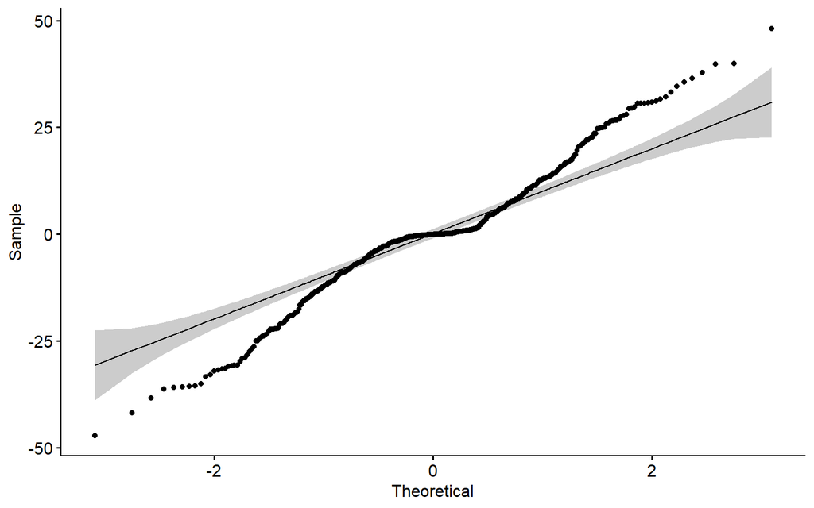

```r
# Check normality
# Build the linear model
model  <- lm(FORMULA, data = dat.used)
# Create a QQ plot of residuals
ggqqplot(residuals(model))
```

```r
#Check for variance homogeneity
# Compute Shapiro-Wilk test of normality
shapiro_test(residuals(model))
```

```
## # A tibble: 1 × 3
##   variable         statistic       p.value
##   <chr>                <dbl>         <dbl>
## 1 residuals(model)     0.967 0.00000000315
```

```r
dat.used %>% levene_test(FORMULA)
```

```
## # A tibble: 1 × 4
##     df1   df2 statistic        p
##   <int> <int>     <dbl>    <dbl>
## 1    29   474      9.10 2.22e-30
```

```r
# Save result
EQUAL.VAR <- dat.used %>% levene_test(FORMULA) %>% pull(p) > 0.05

## Abundance data is not normally distributed and does not have equal variance
## We use Wilcoxon and Kruskal-Wallis

# Plot for comparing diet influence
# Statistics costumed for facet plotting
stat.in <- dat.used %>%
  group_by(day,Phylum) %>%
  wilcox_test(as.formula("Abundance ~ feed")) %>%
  adjust_pvalue(method = "BH") %>%
  add_significance() %>%
  add_xy_position(x = "day", dodge = 0.8) %>%
  p_format("p.adj", accuracy = 0.001, trailing.zero = TRUE, new.col = TRUE)
stat.in
```

```
## # A tibble: 15 × 17
##    day   Phylum      .y.   group1 group2    n1    n2 statistic        p    p.adj
##  * <fct> <fct>       <chr> <chr>  <chr>  <int> <int>     <dbl>    <dbl>    <dbl>
##  1 d21   Firmicutes  Abun… HF     LF        12    12        28 1   e- 2 1.15e- 2
##  2 d21   Bacteroide… Abun… HF     LF        12    12       117 8.29e- 3 1.04e- 2
##  3 d21   Proteobact… Abun… HF     LF        12    12        14 3.71e- 4 6.96e- 4
##  4 d16   Firmicutes  Abun… HF     LF        12    12        17 8.58e- 4 1.29e- 3
##  5 d16   Bacteroide… Abun… HF     LF        12    12       122 2.91e- 3 3.97e- 3
##  6 d16   Proteobact… Abun… HF     LF        12    12         0 7.4 e- 7 2.22e- 6
##  7 d12   Firmicutes  Abun… HF     LF        12    12        40 6.84e- 2 6.84e- 2
##  8 d12   Bacteroide… Abun… HF     LF        12    12       104 6.84e- 2 6.84e- 2
##  9 d12   Proteobact… Abun… HF     LF        12    12         2 2.96e- 6 7.4 e- 6
## 10 d08   Firmicutes  Abun… HF     LF        24    24       125 5.57e- 4 9.28e- 4
## 11 d08   Bacteroide… Abun… HF     LF        24    24       464 1.72e- 4 3.69e- 4
## 12 d08   Proteobact… Abun… HF     LF        24    24        19 1.29e-10 9.68e-10
## 13 d0    Firmicutes  Abun… HF     LF        24    24        52 1.04e- 7 3.90e- 7
## 14 d0    Bacteroide… Abun… HF     LF        24    24       533 2.26e- 8 1.13e- 7
## 15 d0    Proteobact… Abun… HF     LF        24    24         3 4.34e-13 6.51e-12
## # ℹ 7 more variables: p.adj.signif <chr>, y.position <dbl>,
## #   groups <named list>, x <dbl>, xmin <dbl>, xmax <dbl>, p.adj.format <chr>
```

```r
stat.out <- dat.used %>%
  group_by(Phylum) %>%
  kruskal_test(as.formula("Abundance ~ day")) %>%
  add_significance() %>%
  p_format("p", accuracy = 0.001, trailing.zero = TRUE, new.col = TRUE)
stat.out
```

```
## # A tibble: 3 × 9
##   Phylum         .y.          n statistic    df       p method p.signif p.format
## * <fct>          <chr>    <int>     <dbl> <int>   <dbl> <chr>  <chr>    <chr>
## 1 Firmicutes     Abundan…   168      9.71     4 0.0456  Krusk… *        0.0456
## 2 Bacteroidetes  Abundan…   168      9.36     4 0.0527  Krusk… ns       0.0527
## 3 Proteobacteria Abundan…   168     16.1      4 0.00284 Krusk… **       0.0028
```

```r
stat.out2 <- dat.used %>%
  group_by(Phylum) %>%
  dunn_test(as.formula("Abundance ~ day"), p.adjust.method = "fdr") %>%
  add_significance() %>%
  add_xy_position(x = "day") %>%
  p_format("p.adj", accuracy = 0.001, trailing.zero = TRUE, new.col = TRUE)
stat.out2
```

```
## # A tibble: 30 × 15
##    Phylum    .y.   group1 group2    n1    n2 statistic      p p.adj p.adj.signif
##  * <fct>     <chr> <chr>  <chr>  <int> <int>     <dbl>  <dbl> <dbl> <chr>
##  1 Firmicut… Abun… d21    d16       24    24    0.457  0.648  0.768 ns
##  2 Firmicut… Abun… d21    d12       24    24    0.398  0.691  0.768 ns
##  3 Firmicut… Abun… d21    d08       24    48   -1.16   0.247  0.411 ns
##  4 Firmicut… Abun… d21    d0        24    48   -1.87   0.0621 0.207 ns
##  5 Firmicut… Abun… d16    d12       24    24   -0.0593 0.953  0.953 ns
##  6 Firmicut… Abun… d16    d08       24    48   -1.69   0.0918 0.212 ns
##  7 Firmicut… Abun… d16    d0        24    48   -2.39   0.0167 0.100 ns
##  8 Firmicut… Abun… d12    d08       24    48   -1.62   0.106  0.212 ns
##  9 Firmicut… Abun… d12    d0        24    48   -2.32   0.0201 0.100 ns
## 10 Firmicut… Abun… d08    d0        48    48   -0.867  0.386  0.552 ns
## # ℹ 20 more rows
## # ℹ 5 more variables: y.position <dbl>, groups <named list>, xmin <dbl>,
## #   xmax <dbl>, p.adj.format <chr>
```

```r
dat.used$feed <- factor(as.character(dat.used$feed))

df.both <- subset(df.both, Phylum %in% c("Firmicutes", "Bacteroidetes", "Proteobacteria"))
df.both$Phylum <- factor(df.both$Phylum, levels = c(l))
df.both$day <- factor(df.both$day, levels = c(d))

df.both
```

```
## # A tibble: 30 × 8
##    feed  day   treatment feed_treat Others_FB FB_ratio Phylum         Abundance
##    <chr> <fct> <chr>     <chr>          <dbl>    <dbl> <fct>              <dbl>
##  1 HF    d0    both      HF_both         2.03    0.482 Firmicutes         31.8
##  2 HF    d0    both      HF_both         2.03    0.482 Bacteroidetes      66.1
##  3 HF    d0    both      HF_both         2.03    0.482 Proteobacteria      0
##  4 HF    d08   both      HF_both         5.40    0.830 Firmicutes         42.9
##  5 HF    d08   both      HF_both         5.40    0.830 Bacteroidetes      51.7
##  6 HF    d08   both      HF_both         5.40    0.830 Proteobacteria      1.41
##  7 HF    d12   both      HF_both         2.39    1.34  Firmicutes         55.9
##  8 HF    d12   both      HF_both         2.39    1.34  Bacteroidetes      41.7
##  9 HF    d12   both      HF_both         2.39    1.34  Proteobacteria      0
## 10 HF    d16   both      HF_both         3.89    1.03  Firmicutes         48.8
## # ℹ 20 more rows
```

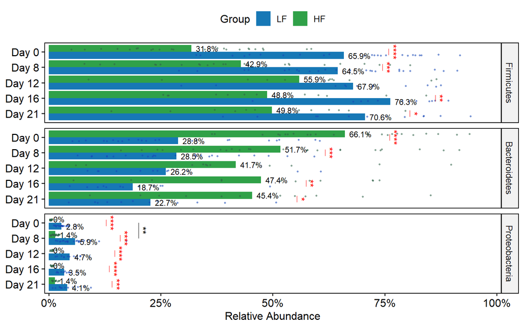

```r
# Plot check PFOS
p.feed <- ggplot(dat.used, aes()) +
  geom_bar(data = df.both, aes(fill = fct_rev(feed), y = Abundance, x = day), stat = "identity", position = position_dodge()) +
  geom_point(data = dat.used, aes(x = day, y = Abundance, color = fct_rev(feed)), position = position_jitterdodge(jitter.width = 0.2, dodge.width = 0.8), size = 0.5, alpha = 0.5) +
  facet_grid(Phylum ~ .) +
  geom_text(data = df.both, aes(label = paste0(round(Abundance,1),"%"), x = day, y = Abundance+1, group = fct_rev(feed)), position = position_dodge(width = 0.9), size = 3, hjust = 0) +
  coord_flip() +
  scale_fill_manual(values = params$COLFEED, name = "Group")+
  scale_color_manual(values = c("LF" = "#1748b6","HF" = "#306148")) +
  theme_pubr(legend = "top", border = TRUE) +
  scale_x_discrete(name = "Day", labels = c("d0" = "Day 0","d08" = "Day 8","d12" = "Day 12","d16" = "Day 16","d21" = "Day 21")) +
  theme(axis.title.y = element_blank()) +
  guides(color = "none")

p.done <- p.feed + stat_pvalue_manual(stat.in, label = "p.adj.signif", tip.length = 0, hide.ns = TRUE, color = "red", coord.flip = TRUE, y.position = c(80.6,55.4,14.1,86.3,57.4,13.5,14.7,74.5,61.7,15.9,75.9,76.1,12.8)) +
  stat_pvalue_manual(stat.out2, label = "p.adj.signif", tip.length = 0, hide.ns = TRUE, coord.flip = TRUE, y.position = c(20)) +
  scale_y_continuous(labels = function(x) paste0(x, "%"), name = "Relative Abundance", limits = c(0,100), expand = c(0.01,0.01))
p.done
```

```r
ggsave(filename = "plots/relative_abundance/Major_phyla_abundance.png", plot = p.done, device = "png", unit = "mm", dpi = 300, height = 200, width = 200)
ggsave(filename = "plots/relative_abundance/Major_phyla_abundance.pdf", plot = p.done, device = "pdf", unit = "mm", dpi = 300, height = 200, width = 200)

# Plot for comparing treatment influence
# Statistics costumed for facet plotting
df.all <- subset(df.all, Phylum %in% c("Firmicutes", "Bacteroidetes", "Proteobacteria"))
df.all$Phylum <- factor(df.all$Phylum, levels = c(l))
df.all$day <- factor(df.all$day, levels = c(d))
dat.used$day <- factor(dat.used$day, levels = c(d))
dat.used$feed <- factor(dat.used$feed, levels = c("LF","HF"))
df.all$feed <- factor(df.all$feed, levels = c("LF","HF"))

stat.in_2 <- dat.used %>%
  group_by(feed,day,Phylum) %>%
  wilcox_test(as.formula("Abundance ~ feed_treat")) %>%
  adjust_pvalue(method = "BH") %>%
  add_significance() %>%
  add_xy_position(x = "feed", dodge = 0.8) %>%
  p_format("p.adj", accuracy = 0.001, trailing.zero = TRUE, new.col = TRUE)
stat.in_2
```

```
## # A tibble: 30 × 18
##    day   feed  Phylum      .y.   group1 group2    n1    n2 statistic     p p.adj
##  * <fct> <fct> <fct>       <chr> <chr>  <chr>  <int> <int>     <dbl> <dbl> <dbl>
##  1 d21   LF    Firmicutes  Abun… LF_CT… LF_PF…     6     6        27 0.18  0.661
##  2 d21   LF    Bacteroide… Abun… LF_CT… LF_PF…     6     6        10 0.24  0.661
##  3 d21   LF    Proteobact… Abun… LF_CT… LF_PF…     6     6         8 0.132 0.661
##  4 d16   LF    Firmicutes  Abun… LF_CT… LF_PF…     6     6        25 0.31  0.661
##  5 d16   LF    Bacteroide… Abun… LF_CT… LF_PF…     6     6        13 0.485 0.661
##  6 d16   LF    Proteobact… Abun… LF_CT… LF_PF…     6     6         8 0.132 0.661
##  7 d12   LF    Firmicutes  Abun… LF_CT… LF_PF…     6     6        23 0.485 0.661
##  8 d12   LF    Bacteroide… Abun… LF_CT… LF_PF…     6     6        13 0.485 0.661
##  9 d12   LF    Proteobact… Abun… LF_CT… LF_PF…     6     6        16 0.818 0.818
## 10 d08   LF    Firmicutes  Abun… LF_CT… LF_PF…    12    12        93 0.242 0.661
## # ℹ 20 more rows
## # ℹ 7 more variables: p.adj.signif <chr>, y.position <dbl>,
## #   groups <named list>, x <dbl>, xmin <dbl>, xmax <dbl>, p.adj.format <chr>
```

```r
stat.out_2 <- dat.used %>%
  group_by(day,Phylum) %>%
  wilcox_test(as.formula("Abundance ~ feed")) %>%
  adjust_pvalue(method = "BH") %>%
  add_significance() %>%
  add_xy_position(x = "feed", dodge = 0.8) %>%
  p_format("p.adj", accuracy = 0.001, trailing.zero = TRUE, new.col = TRUE)
stat.out_2
```

```
## # A tibble: 15 × 16
##    day   Phylum      .y.   group1 group2    n1    n2 statistic        p    p.adj
##  * <fct> <fct>       <chr> <chr>  <chr>  <int> <int>     <dbl>    <dbl>    <dbl>
##  1 d21   Firmicutes  Abun… LF     HF        12    12       116 1   e- 2 1.15e- 2
##  2 d21   Bacteroide… Abun… LF     HF        12    12        27 8.29e- 3 1.04e- 2
##  3 d21   Proteobact… Abun… LF     HF        12    12       130 3.71e- 4 6.96e- 4
##  4 d16   Firmicutes  Abun… LF     HF        12    12       127 8.58e- 4 1.29e- 3
##  5 d16   Bacteroide… Abun… LF     HF        12    12        22 2.91e- 3 3.97e- 3
##  6 d16   Proteobact… Abun… LF     HF        12    12       144 7.4 e- 7 2.22e- 6
##  7 d12   Firmicutes  Abun… LF     HF        12    12       104 6.84e- 2 6.84e- 2
##  8 d12   Bacteroide… Abun… LF     HF        12    12        40 6.84e- 2 6.84e- 2
##  9 d12   Proteobact… Abun… LF     HF        12    12       142 2.96e- 6 7.4 e- 6
## 10 d08   Firmicutes  Abun… LF     HF        24    24       451 5.57e- 4 9.28e- 4
## 11 d08   Bacteroide… Abun… LF     HF        24    24       112 1.72e- 4 3.69e- 4
## 12 d08   Proteobact… Abun… LF     HF        24    24       557 1.29e-10 9.68e-10
## 13 d0    Firmicutes  Abun… LF     HF        24    24       524 1.04e- 7 3.90e- 7
## 14 d0    Bacteroide… Abun… LF     HF        24    24        43 2.26e- 8 1.13e- 7
## 15 d0    Proteobact… Abun… LF     HF        24    24       573 4.34e-13 6.51e-12
## # ℹ 6 more variables: p.adj.signif <chr>, y.position <dbl>,
## #   groups <named list>, xmin <dbl>, xmax <dbl>, p.adj.format <chr>
```

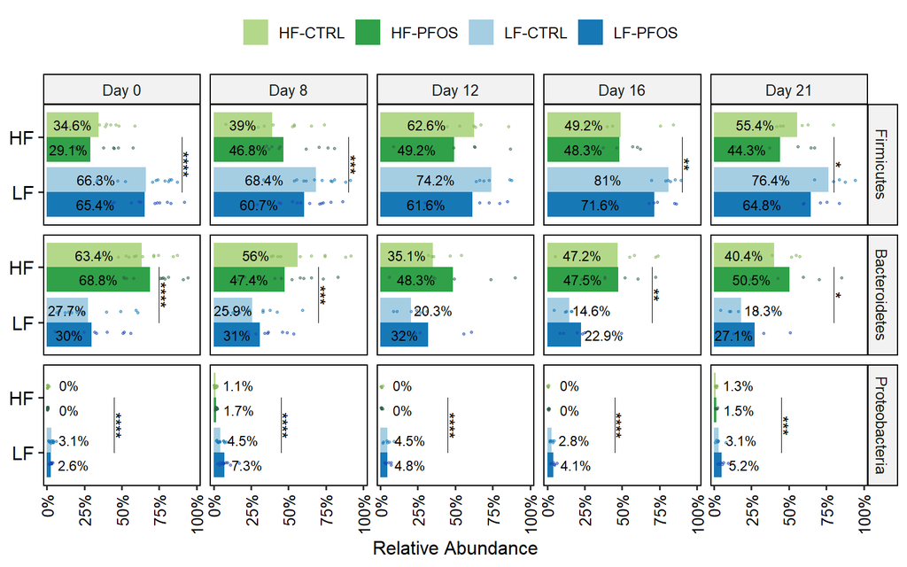

```r
dat.used$feed_treat <- factor(as.character(dat.used$feed_treat))

d <- c("d0","d08","d12","d16","d21")

df.all <- subset(df.all, Phylum %in% c("Firmicutes", "Bacteroidetes", "Proteobacteria"))
df.all$Phylum <- factor(df.all$Phylum, levels = c(l))
df.all$day <- factor(df.all$day, levels = c(d))
dat.used$day <- factor(dat.used$day, levels = c(d))
dat.used$feed <- factor(dat.used$feed, levels = c("LF","HF"))
df.all$feed <- factor(df.all$feed, levels = c("LF","HF"))

p.fig <- ggplot(dat.used) +
  geom_bar(data = df.all, aes(fill = fct_rev(feed_treat), y = Abundance, x = feed), stat = "identity", position = position_dodge()) +
  geom_point(data = dat.used, aes(x = feed, y = Abundance, color = fct_rev(feed_treat)), position = position_jitterdodge(jitter.width = 0.2, dodge.width = 0.8), size = 0.5, alpha = 0.5) +
  geom_text(data = df.all, aes(label = paste0(round(Abundance,1),"%"), x = feed, y = ifelse(Abundance<25, Abundance+15, Abundance/2), group = fct_rev(feed_treat)), position = position_dodge(width = 0.9), size = 3, hjust = 0.5) +
  facet_grid(Phylum ~ day, labeller = labeller(day = c("d0" = "Day 0","d08" = "Day 8","d12" = "Day 12","d16" = "Day 16","d21" = "Day 21"))) +
  coord_flip() +
  scale_fill_manual(values = params$COL, name = "", labels = c("LF_CTRL" = "LF-CTRL","LF_PFOS" = "LF-PFOS","HF_CTRL" = "HF-CTRL","HF_PFOS" = "HF-PFOS"), breaks = c("HF_CTRL", "HF_PFOS","LF_CTRL","LF_PFOS")) +
  scale_color_manual(values = c("LF_CTRL" = "#1778b6","LF_PFOS" = "#1748b6","HF_CTRL" = "#84b559","HF_PFOS" = "#306148")) +
  theme_pubr(legend = "top", border = TRUE) +
  scale_x_discrete(name = "Feed") +
  theme(axis.title.y = element_blank(),
        axis.text.x = element_text(size = 10, angle = 90, vjust = 0.5, hjust = 1)) +
  guides(color = "none")

p.fig1 <- p.fig + stat_pvalue_manual(stat.in_2, label = "p.adj.signif", tip.length = 0, hide.ns = TRUE, color = "red", coord.flip = TRUE) +
  stat_pvalue_manual(stat.out_2, label = "p.adj.signif", tip.length = 0, hide.ns = TRUE, coord.flip = TRUE, y.position = c(80,80,45,90,70,45,45,90,70,45,90,75,45)) +
  scale_y_continuous(labels = function(x) paste0(x, "%"), name = "Relative Abundance", limits = c(0,100), expand = c(0.025,0.025))
p.fig1
```

```r
ggsave(filename = "plots/relative_abundance/SUP_-_Figure_A4_Major_phyla_abundance_by_day.png", plot = p.fig1, device = "png", unit = "mm", dpi = 300, height = 150, width = 200)
ggsave(filename = "plots/relative_abundance/SUP_-_Figure_A4_Major_phyla_abundance_by_day.pdf", plot = p.fig1, device = "pdf", unit = "mm", dpi = 300, height = 150, width = 200)


## SUPPLEMENTING FIGURE FOR PFOS EFFECT ON ABUNDANCES FOR ALL DATA EXCLUDING DAY 0

dat.1 <- subset(dat.used, day != "d0")
df.1 <- subset(df.all, day != "d0")
dat.1$feed <- factor(dat.1$feed, levels = c("LF","HF"))
df.1$feed <- factor(df.1$feed, levels = c("LF","HF"))

stat.in_3 <- dat.used %>%
  group_by(feed,Phylum) %>%
  wilcox_test(as.formula("Abundance ~ feed_treat")) %>%
  adjust_pvalue(method = "BH") %>%
  add_significance() %>%
  add_xy_position(x = "feed", dodge = 0.8) %>%
  p_format("p.adj", accuracy = 0.001, trailing.zero = TRUE, new.col = TRUE)
stat.in_3
```

```
## # A tibble: 6 × 17
##   feed  Phylum         .y.       group1 group2    n1    n2 statistic     p p.adj
## * <fct> <fct>          <chr>     <chr>  <chr>  <int> <int>     <dbl> <dbl> <dbl>
## 1 LF    Firmicutes     Abundance LF_CT… LF_PF…    42    42      1120 0.033 0.084
## 2 LF    Bacteroidetes  Abundance LF_CT… LF_PF…    42    42       651 0.039 0.084
## 3 LF    Proteobacteria Abundance LF_CT… LF_PF…    42    42       655 0.042 0.084
## 4 HF    Firmicutes     Abundance HF_CT… HF_PF…    42    42       959 0.496 0.595
## 5 HF    Bacteroidetes  Abundance HF_CT… HF_PF…    42    42       828 0.634 0.634
## 6 HF    Proteobacteria Abundance HF_CT… HF_PF…    42    42       690 0.087 0.130
## # ℹ 7 more variables: p.adj.signif <chr>, y.position <dbl>,
## #   groups <named list>, x <dbl>, xmin <dbl>, xmax <dbl>, p.adj.format <chr>
```

```r
stat.out_3 <- dat.used %>%
  group_by(Phylum) %>%
  wilcox_test(as.formula("Abundance ~ feed")) %>%
  adjust_pvalue(method = "BH") %>%
  add_significance() %>%
  add_xy_position(x = "feed", dodge = 0.8) %>%
  p_format("p.adj", accuracy = 0.001, trailing.zero = TRUE, new.col = TRUE)
stat.out_3
```

```
## # A tibble: 3 × 15
##   Phylum         .y.       group1 group2    n1    n2 statistic        p    p.adj
## * <fct>          <chr>     <chr>  <chr>  <int> <int>     <dbl>    <dbl>    <dbl>
## 1 Firmicutes     Abundance LF     HF        84    84      5759 1.49e-12 1.49e-12
## 2 Bacteroidetes  Abundance LF     HF        84    84      1196 1.4 e-13 2.10e-13
## 3 Proteobacteria Abundance LF     HF        84    84      6765 9.92e-25 2.98e-24
## # ℹ 6 more variables: p.adj.signif <chr>, y.position <dbl>,
## #   groups <named list>, xmin <dbl>, xmax <dbl>, p.adj.format <chr>
```

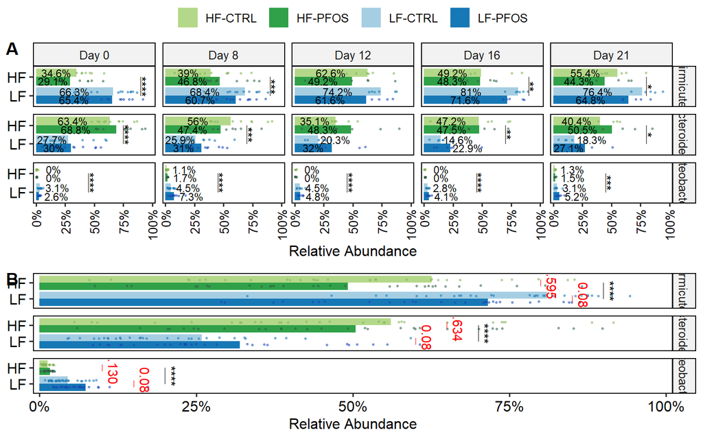

```r
p.all <- ggplot(dat.1) +
  geom_bar(data = df.1, aes(fill = fct_rev(feed_treat), y = Abundance, x = feed), stat = "identity", position = position_dodge()) +
  geom_point(data = dat.1, aes(x = feed, y = Abundance, color = fct_rev(feed_treat)), position = position_jitterdodge(jitter.width = 0.2, dodge.width = 0.8), size = 0.5, alpha = 0.5) +
  # geom_text(data = df.all, aes(label = paste0(round(Abundance,1),"%"), x = feed, y = ifelse(Abundance<25, Abundance+15, Abundance/2), group = fct_rev(feed_treat)), position = position_dodge(width = 0.9), size = 3, hjust = 0.5) +
  facet_grid(Phylum ~ .) +
  coord_flip() +
  scale_fill_manual(values = params$COL, name = "All data (Day 8 - 21)", labels = c("LF_CTRL" = "LF-CTRL","LF_PFOS" = "LF-PFOS","HF_CTRL" = "HF-CTRL","HF_PFOS" = "HF-PFOS"), breaks = c("HF_CTRL", "HF_PFOS","LF_CTRL","LF_PFOS"))+
  scale_color_manual(values = c("LF_CTRL" = "#1778b6","LF_PFOS" = "#1748b6","HF_CTRL" = "#84b559","HF_PFOS" = "#306148")) +
  theme_pubr(legend = "top", border = TRUE) +
  scale_x_discrete(name = "Feed") +
  theme(axis.title.y = element_blank()) +
  guides(color = "none")

p.fig2 <- p.all+ stat_pvalue_manual(stat.in_3, label = "p.adj.format", tip.length = 0, hide.ns = FALSE, color = "red", coord.flip = TRUE, y.position = c(85,60,15,80,65,10)) +
  stat_pvalue_manual(stat.out_3, label = "p.adj.signif", tip.length = 0, hide.ns = TRUE, coord.flip = TRUE, y.position = c(90,70,20)) +
  scale_y_continuous(labels = function(x) paste0(x, "%"), name = "Relative Abundance", limits = c(0,100), expand = c(0.01,0.01))

ggsave(filename = "plots/relative_abundance/Excluding_D0_phyla_abundance_all.png", plot = p.fig2, device = "png", unit = "mm", dpi = 300, height = 100, width = 200)
ggsave(filename = "plots/relative_abundance/Excluding_D0_phyla_abundance_all.pdf", plot = p.fig2, device = "pdf", unit = "mm", dpi = 300, height = 100, width = 200)

p.final <- ggarrange(p.fig1, p.fig2,
                     ncol = 1, nrow = 2,
                     common.legend = TRUE,
                     heights = c(4,3),
                     labels = c("A","B"))
p.final
```

```r
ggsave(filename = "plots/figures/final_figures_Appendix/Figure A.5.png", plot = p.final, device = "png", unit = "mm", dpi = 300, height = 220, width = 200)
ggsave(filename = "plots/figures/final_figures_Appendix/Figure A.5.pdf", plot = p.final, device = "pdf", unit = "mm", dpi = 300, height = 220, width = 200)

# clear the environment and release memory
rm(list = ls(all.names = TRUE))
invisible(gc())
```

# FINAL COMMENT

This completes the microbiome description.

To begin the statistical analysis of the data you are now ready for the following steps:

| Analysis | Template | Note |
| --- | --- | --- |
| Statistical testing | GMH_test_variables | Statistical test and visualization of alpha diversity and metadata |
| Beta diversity | GMH_beta_diveristy | Statistical test and visualization of beta diversity |
| Differential abundance | GMH_differential_abundance | Test differential abundance of taxa against sample variables |

# SETTINGS

Overview of the parameters and packages that were used for this Rmarkdown.

## PARAMETERS

The following paramenters were set in for this analysis:

```r
params <- readRDS("R_objects/params_description.RDS")


tmp <- unlist(params)
dat <- data.frame(Parameter = names(tmp), Value = unname(tmp))


kbl(dat, row.names = F) %>% kable_classic(lightable_options = "striped")
```

| Parameter | Value |
| --- | --- |
| input | R_objects/Phyloseq.Rdata |
| group_var | feed_treat |
| subject_var | rat_name |
| time_var | day |
| COL.LF_CTRL | #a5cee3 |
| COL.LF_PFOS | #1778b6 |
| COL.HF_CTRL | #b4d88a |
| COL.HF_PFOS | #30a148 |
| COLFEED.LF | #1778b6 |
| COLFEED.HF | #30a148 |